# Geospatial Correlation Analysis of House Pricing

Alex Alvarez

2022-11-22

## Carga de libraries

```r
set.seed(42) # Reproducibilidad
pacman::p_load(rgdal, rgeos, stars, spatstat, spdep, sf, raster,
               spatialreg, tidyverse, gstat, MASS, corrplot, patchwork)
```

## Datos Censo

```r
censo_iq <- readRDS("mz_censo17_iquique.rds")
mz_iq <- censo_iq  %>%
  st_as_sf() %>%
  st_transform(32719)

# imputación de escolaridad por la media
mz_iq$JH_ESC_P[is.na(mz_iq$JH_ESC_P)] <- mean(mz_iq$JH_ESC_P,na.rm = TRUE)
```

## Raster Interpolando por Escolaridad

```r
gs <- gstat(formula = JH_ESC_P~1, locations = mz_iq)

rast <- raster(mz_iq, res=30)

idw <- interpolate(rast, gs)
```

```
## [inverse distance weighted interpolation]
```

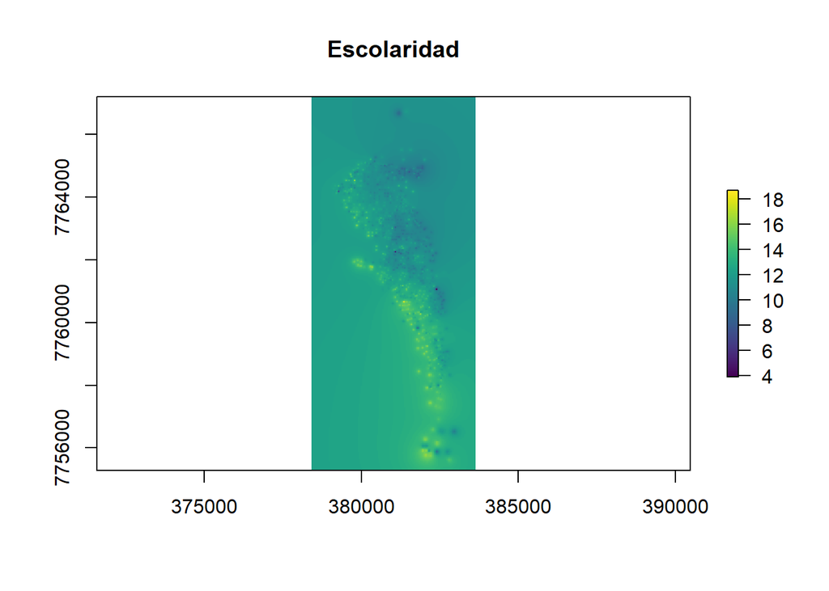

```r
lim <- extent(idw) # para recuperar los límites del raster más adelante

plot(idw, col = viridis::viridis(100), main='Escolaridad')
```

> Se aprecia Mayor escolaridad en la línea costera

## Datos SII

```r
SII_iq <- readRDS("mz_SII_iquique.rds")
mzs_iq <- SII_iq  %>%
  st_as_sf() %>%
  st_transform(32719)

# Metros cuadrados de Com + Of
mzs_iq$MtOfCom <- mzs_iq$oficinas + mzs_iq$comercio
# Densidad: Com + Of / Area
mzs_iq$OfComDens <- mzs_iq$MtOfCom / mzs_iq$AREA
```

## Raster kernel density para MtOfCom (puntos sobre el 5% del área de cada polígono)

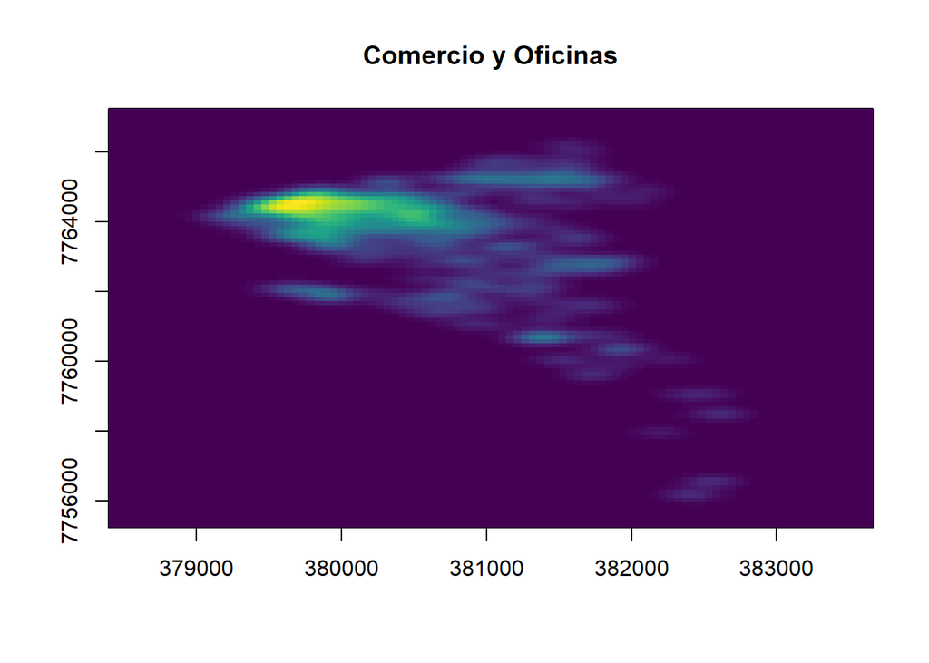

```r
mzs_iqF <- mzs_iq[mzs_iq$OfComDens > 0.05,] #umbral para puntos de MtOfCom sobre 0.05 del Area

pts <- st_centroid(mzs_iqF$geometry) %>% unlist() %>% matrix(nrow=2) %>% t()

kden <- kde2d(pts[,1], pts[,2], h= 500, n = 100, lims = c(lim[1:2],lim[3:4]))
image(kden, col = viridis::viridis(100), main='Comercio y Oficinas')
```

## Rasters Interpolando por Comercio + Oficinas y su Densidad

```r
gs2 <- gstat(formula = MtOfCom~1, locations = mzs_iq)
gs3 <- gstat(formula = OfComDens~1, locations = mzs_iqF)

rast2 <- raster(mzs_iq, res=30)

idw2 <- interpolate(rast2, gs2)
```

```
## [inverse distance weighted interpolation]
```

```r
idw3 <- interpolate(rast2, gs3)
```

```
## [inverse distance weighted interpolation]
```

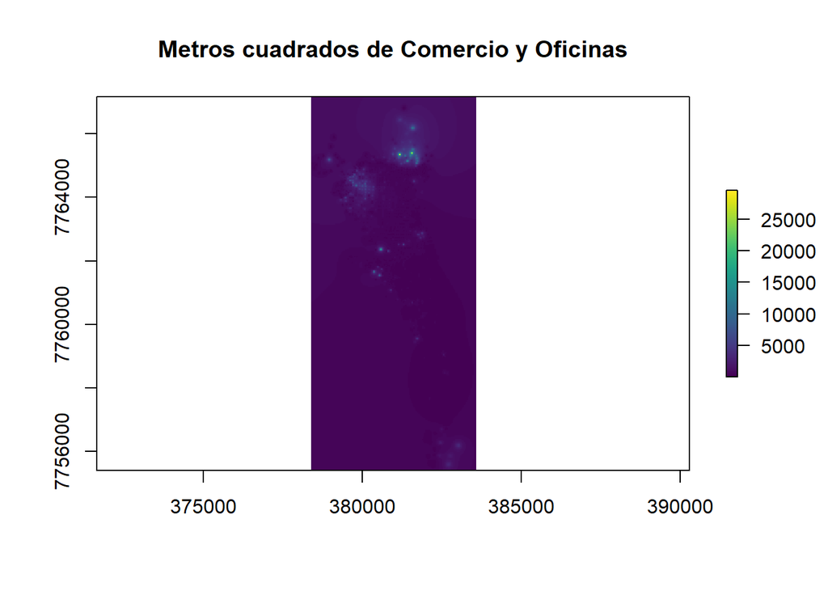

```r
plot(idw2, col = viridis::viridis(100), main='Metros cuadrados de Comercio y Oficinas')
```

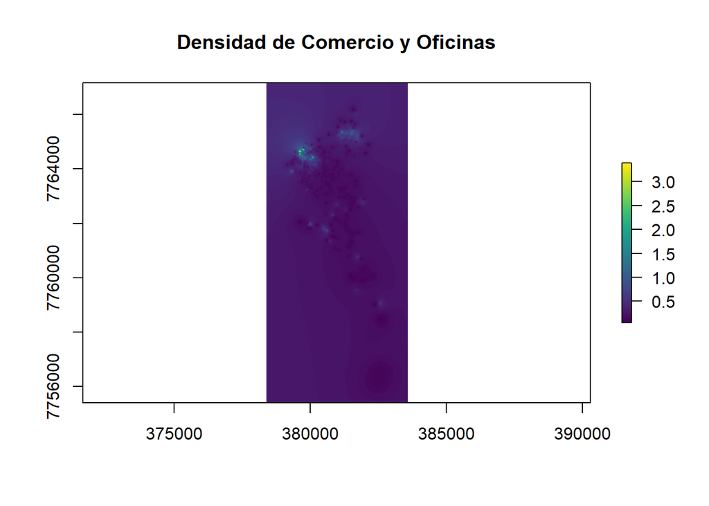

```r
plot(idw3, col = viridis::viridis(100), main='Densidad de Comercio y Oficinas')
```

> Se asume que Densidad de Comercio + Oficinas representa de mejor manera la agregación de ambos datos, al estar estandarizado por el área del polígono del cual se extraen, por lo tanto, la interpolación de está deberá ser más representativa de la geoespacialidad

## Carga de Data Tasación e imputación de los rasters anteriores

```r
tas_iq <- readRDS("tasacion_iquique.rds")  %>%
            st_as_sf() %>%
            st_transform(32719)

# imputación
tas_iq$escolaridad <- raster::extract(idw, tas_iq) # Escolaridad
tas_iq$MtOfCom <- raster::extract(idw2, tas_iq) # Metros cuadrados de Com + Ofs
tas_iq$OfComDens <- raster::extract(idw3, tas_iq) # Densidad de Com + Ofs interpolada
tas_iq$MtOfComK <- raster::extract(raster(kden), tas_iq) # kernel density para MtOfCom
```

## OLS

```r
m.ols <- lm(tasa_uf ~ sup_const + sup_terr + escolaridad + casa + ascensor + MtOfCom + MtOfComK + OfComDens, data = tas_iq)
summary(m.ols)
```

```
##
## Call:
## lm(formula = tasa_uf ~ sup_const + sup_terr + escolaridad + casa +
##     ascensor + MtOfCom + MtOfComK + OfComDens, data = tas_iq)
##
## Residuals:
##     Min      1Q  Median      3Q     Max
## -5965.1  -590.9    38.0   563.1  3773.0
##
## Coefficients:
##               Estimate Std. Error t value Pr(>|t|)
## (Intercept) -4.861e+03  6.809e+02  -7.139 4.21e-12 ***
## sup_const    2.285e+01  1.085e+00  21.064  < 2e-16 ***
## sup_terr     1.754e+01  7.535e-01  23.274  < 2e-16 ***
## escolaridad  4.756e+02  4.755e+01  10.003  < 2e-16 ***
## casa        -2.262e+03  2.658e+02  -8.512 3.13e-16 ***
## ascensor     6.557e+02  2.356e+02   2.783  0.00564 **
## MtOfCom      2.884e-01  1.142e-01   2.526  0.01191 *
## MtOfComK    -2.514e+09  1.285e+09  -1.956  0.05117 .
## OfComDens   -2.850e+02  5.658e+02  -0.504  0.61467
## ---
## Signif. codes:  0 '***' 0.001 '**' 0.01 '*' 0.05 '.' 0.1 ' ' 1
##
## Residual standard error: 1111 on 416 degrees of freedom
## Multiple R-squared:  0.9238, Adjusted R-squared:  0.9224
## F-statistic: 630.8 on 8 and 416 DF,  p-value: < 2.2e-16
```

## Matriz de Vecinos y error espacial

```r
nb <- nb2listw(neighbours = knn2nb(
  knn = knearneigh(x = tas_iq, k = 5)),
  style = "W")
# se alcanzó mayor autocorrelación con k = 5

moran.test(m.ols$residuals, nb)
```

```
##
##  Moran I test under randomisation
##
## data:  m.ols$residuals
## weights: nb
##
## Moran I statistic standard deviate = 8.5505, p-value < 2.2e-16
## alternative hypothesis: greater
## sample estimates:
## Moran I statistic       Expectation          Variance
##      0.2390527912     -0.0023584906      0.0007971408
```

> El Índice de Moran es 0.2390 y el p-valor significativo, por lo que se puede asumir que existe autocorrelación espacial de la variable tasa_uf (medida con los residuos del modelo)

## Modelos de regresion espacial

### Con error espacial

```r
# NOTA: se quitará MtOfComK correspondiente al kernel density, ya que no permite llevar a cabo los modelos de correlación espacial.
# Por otro lado, se asume que OfComDens representa de mejor manera tal variable al estar estandarizada por área del polígono

m.err <- errorsarlm(tasa_uf ~ sup_const + sup_terr + escolaridad + casa + ascensor + MtOfCom + OfComDens, data
                    = tas_iq, listw = nb, etype="error", method="eigen")

summary(m.err)
```

```
##
## Call:errorsarlm(formula = tasa_uf ~ sup_const + sup_terr + escolaridad +
##     casa + ascensor + MtOfCom + OfComDens, data = tas_iq, listw = nb,
##     etype = "error", method = "eigen")
##
## Residuals:
##        Min         1Q     Median         3Q        Max
## -5102.4065  -448.8474    -7.0914   436.6326  3415.5404
##
## Type: error
## Coefficients: (asymptotic standard errors)
##                Estimate  Std. Error z value  Pr(>|z|)
## (Intercept) -4.4444e+03  9.4186e+02 -4.7187 2.373e-06
## sup_const    1.9410e+01  9.5637e-01 20.2953 < 2.2e-16
## sup_terr     1.7929e+01  7.1940e-01 24.9219 < 2.2e-16
## escolaridad  4.7879e+02  6.8050e+01  7.0359 1.980e-12
## casa        -2.2018e+03  2.4508e+02 -8.9842 < 2.2e-16
## ascensor     3.4883e+02  2.1871e+02  1.5950    0.1107
## MtOfCom      1.7139e-02  1.4132e-01  0.1213    0.9035
## OfComDens    1.4603e+02  7.0014e+02  0.2086    0.8348
##
## Lambda: 0.5385, LR test value: 66.062, p-value: 4.4409e-16
## Asymptotic standard error: 0.046969
##     z-value: 11.465, p-value: < 2.22e-16
## Wald statistic: 131.44, p-value: < 2.22e-16
##
## Log likelihood: -3547.988 for error model
## ML residual variance (sigma squared): 983700, (sigma: 991.82)
## Number of observations: 425
## Number of parameters estimated: 10
## AIC: 7116, (AIC for lm: 7180)
```

```r
moran.test(m.err$residuals, nb)
```

```
##
##  Moran I test under randomisation
##
## data:  m.err$residuals
## weights: nb
##
## Moran I statistic standard deviate = -0.0062337, p-value = 0.5025
## alternative hypothesis: greater
## sample estimates:
## Moran I statistic       Expectation          Variance
##     -0.0025344863     -0.0023584906      0.0007970901
```

> El modelo con error espacial logra eliminar la autocorrelación espacial

## Modelo con lag espacial

```r
m.lag <- lagsarlm(tasa_uf ~ sup_const + sup_terr + escolaridad + casa + ascensor + MtOfCom + OfComDens,
                  data = tas_iq, listw = nb, type="lag",method="eigen")

summary(m.lag)
```

```
##
## Call:lagsarlm(formula = tasa_uf ~ sup_const + sup_terr + escolaridad +
##     casa + ascensor + MtOfCom + OfComDens, data = tas_iq, listw = nb,
##     type = "lag", method = "eigen")
##
## Residuals:
##       Min        1Q    Median        3Q       Max
## -4943.182  -552.839    74.965   479.162  3430.228
##
## Type: lag
## Coefficients: (asymptotic standard errors)
##                Estimate  Std. Error z value  Pr(>|z|)
## (Intercept) -3578.91572   635.22114 -5.6341 1.759e-08
## sup_const      21.08439     0.99331 21.2264 < 2.2e-16
## sup_terr       15.09300     0.75032 20.1154 < 2.2e-16
## escolaridad   319.16170    47.08780  6.7780 1.218e-11
## casa        -2001.55490   241.88142 -8.2749 2.220e-16
## ascensor      642.17475   213.46776  3.0083  0.002627
## MtOfCom         0.18640     0.10003  1.8635  0.062394
## OfComDens    -484.70963   475.95150 -1.0184  0.308487
##
## Rho: 0.22316, LR test value: 73.842, p-value: < 2.22e-16
## Asymptotic standard error: 0.024472
##     z-value: 9.119, p-value: < 2.22e-16
## Wald statistic: 83.155, p-value: < 2.22e-16
##
## Log likelihood: -3544.098 for lag model
## ML residual variance (sigma squared): 1016700, (sigma: 1008.3)
## Number of observations: 425
## Number of parameters estimated: 10
## AIC: 7108.2, (AIC for lm: 7180)
## LM test for residual autocorrelation
## test value: 18.19, p-value: 1.9995e-05
```

```r
moran.test(m.lag$residuals, nb)
```

```
##
##  Moran I test under randomisation
##
## data:  m.lag$residuals
## weights: nb
##
## Moran I statistic standard deviate = 4.1274, p-value = 1.834e-05
## alternative hypothesis: greater
## sample estimates:
## Moran I statistic       Expectation          Variance
##      0.1142700252     -0.0023584906      0.0007984669
```

> El incorporar al modelo el lag espacial no elimina la autocorrelación (Moran I = 0.11427 y p-valor = 1.834e-05)

## Modelo con error+lag espacial

```r
m.errlag <- sacsarlm(tasa_uf ~ sup_const + sup_terr + escolaridad + casa + ascensor + MtOfCom + OfComDens,
                     data = tas_iq, listw = nb, type="sac", method="eigen")

summary(m.errlag)
```

```
##
## Call:sacsarlm(formula = tasa_uf ~ sup_const + sup_terr + escolaridad +
##     casa + ascensor + MtOfCom + OfComDens, data = tas_iq, listw = nb,
##     type = "sac", method = "eigen")
##
## Residuals:
##      Min       1Q   Median       3Q      Max
## -5020.75  -480.15    36.21   451.19  3416.77
##
## Type: sac
## Coefficients: (asymptotic standard errors)
##                Estimate  Std. Error z value  Pr(>|z|)
## (Intercept) -3765.17347   813.58480 -4.6279 3.694e-06
## sup_const      19.77687     0.94956 20.8275 < 2.2e-16
## sup_terr       16.62318     0.73829 22.5159 < 2.2e-16
## escolaridad   361.45952    61.43239  5.8839 4.008e-09
## casa        -2105.72422   240.35944 -8.7607 < 2.2e-16
## ascensor      448.68490   213.25218  2.1040   0.03538
## MtOfCom         0.10597     0.12339  0.8588   0.39047
## OfComDens     -67.79554   601.52159 -0.1127   0.91026
##
## Rho: 0.17272
## Asymptotic standard error: 0.029075
##     z-value: 5.9406, p-value: 2.8402e-09
## Lambda: 0.37172
## Asymptotic standard error: 0.064405
##     z-value: 5.7717, p-value: 7.8488e-09
##
## LR test value: 94.205, p-value: < 2.22e-16
##
## Log likelihood: -3533.916 for sac model
## ML residual variance (sigma squared): 948540, (sigma: 973.93)
## Number of observations: 425
## Number of parameters estimated: 11
## AIC: 7089.8, (AIC for lm: 7180)
```

```r
moran.test(m.errlag$residuals, nb)
```

```
##
##  Moran I test under randomisation
##
## data:  m.errlag$residuals
## weights: nb
##
## Moran I statistic standard deviate = 0.012581, p-value = 0.495
## alternative hypothesis: greater
## sample estimates:
## Moran I statistic       Expectation          Variance
##     -0.0020032380     -0.0023584906      0.0007973218
```

> El modelo con error y lag espacial logra eliminar la autocorrelación (AIC: 7089.8, Moran I = -0.00200 y p-value = 0.495), con desempeño similar al modelo que solo incorpora error (AIC: 7116, Moran I = -0.00253 y p-value = 0.5025). Dado el similar desempeño se opta por el modelo con error y lag espacial al resultar este mejor puntuado por criterio de información Akaike. Considerado lo anterior, la variable de entorno con mayor impacto sobre el valor de viviendas es sup_terr (superficie del terreno) con valor-z de 22.5159 y valor-p menor a 2.2e-16.

## Unión de los dataframes consevarvando poligonos y puntos para graficar modelos sobre los polígonos

```r
mz_iq <-  mz_iq %>% mutate(geomPol = geometry)

join_iq  <- st_join(tas_iq, mz_iq, join = st_nearest_feature )

F_iq  <-  join_iq %>% mutate(geomP = geometry,
                          geometry = geomPol) %>%
                   dplyr::select(!c(geomPol))
```

## Agregación de las predicciones

```r
F_iq <-
  F_iq %>%
  mutate(reg_lin = predict(m.ols),
         errsar = fitted(m.err),
         lagsar = fitted(m.lag),
         sacsar = fitted(m.errlag))
```

```
## This method assumes the response is known - see manual page
## This method assumes the response is known - see manual page
## This method assumes the response is known - see manual page
```

## Gráfico

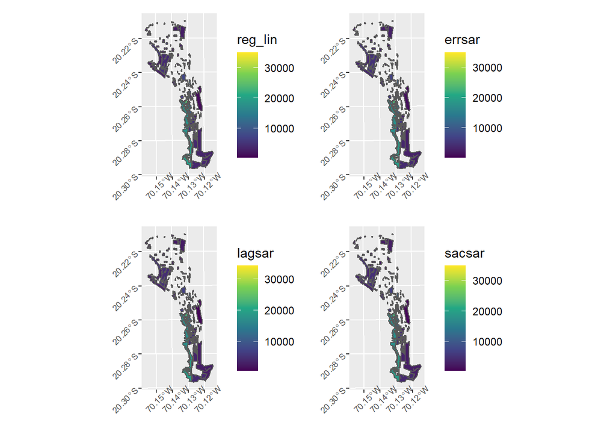

```r
p1 <- ggplot(data=F_iq) +
  geom_sf(aes(fill=reg_lin)) +
  scale_fill_viridis_c()+
  theme(axis.text = element_text(angle = 45, size = 7))

p2 <- ggplot(data=F_iq) +
  geom_sf(aes(fill=errsar)) +
  scale_fill_viridis_c()+
  theme(axis.text = element_text(angle = 45, size = 7))

p3 <- ggplot(data=F_iq) +
  geom_sf(aes(fill=lagsar)) +
  scale_fill_viridis_c()+
  theme(axis.text = element_text(angle = 45, size = 7))

p4 <- ggplot(data=F_iq) +
  geom_sf(aes(fill=sacsar)) +
  scale_fill_viridis_c()+
  theme(axis.text = element_text(angle = 45, size = 7))

(p1 + p2) / (p3 + p4)
```